# Simple Linear Regression IV

## 2016 Election

[figure not shown]

**Question at hand**: How will Obama's 46% approval rating effect his party's candidate for the 2016 presidential election?

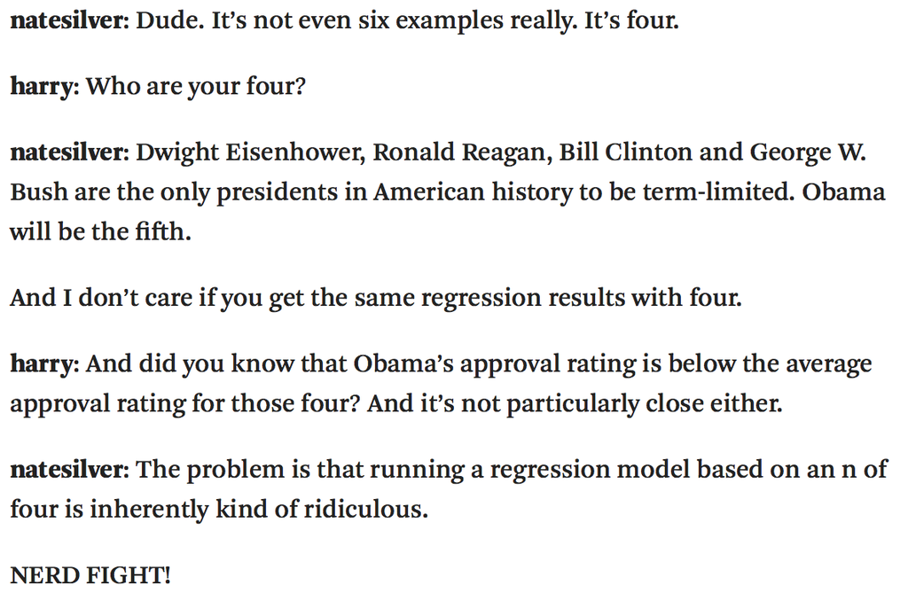

### Why is it ridiculous?

## Unemployment and elections

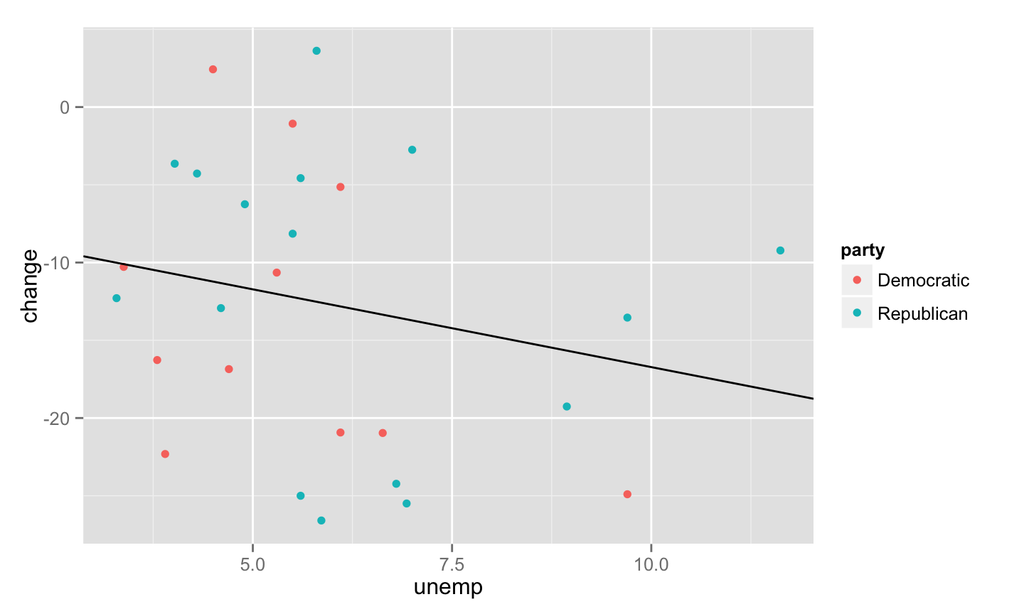

Some evidence of a negative linear relationship between unemployment level and change in party support - or is there?

## H-test for Regression

\(H_0:\) There is no relationship between unemployment level and change in party support.

\[ H_O: \beta_1 = 0 \]

\[ H_A: \beta_1 \neq 0 \]

### Method

- Randomization
- Mathematical Approximation (\(t\))

## H-tests for regression

```r
m0 <- lm(change ~ unemp, data = ump)
summary(m0)
```

```
##
## Call:
## lm(formula = change ~ unemp, data = ump)
##
## Residuals:
##     Min      1Q  Median      3Q     Max
## -14.011  -7.861  -0.183   7.389  16.140
##
## Coefficients:
##             Estimate Std. Error t value Pr(>|t|)
## (Intercept)   -6.714      5.457   -1.23     0.23
## unemp         -1.001      0.872   -1.15     0.26
##
## Residual standard error: 9.11 on 25 degrees of freedom
## Multiple R-squared:  0.0501, Adjusted R-squared:  0.0121
## F-statistic: 1.32 on 1 and 25 DF,  p-value: 0.262
```

## H-tests for regression

- Each line in the summary table is a hypothesis test that the parameter is zero.
- Under certain conditions, the test statistic associated with \(b\)'s is distributed like \(t\) random variables with \(n - p\) degrees of freedom.

\[ \frac{b - \beta}{SE} \sim t_{df = n - p}\]

```r
t_stat <- (-1.0010 - 0)/0.8717
pt(t_stat, df = 27 - 2) * 2
```

```
## [1] 0.262
```

## Question

What do you expect a 95% CI for the slope to look like?

1. \(\beta_1 \pm \frac{b_1 - \beta}{SE}\)
2. \(b_1 \pm 1.96 \times SE\)
3. \(b_1 \pm t^* \times SE\)
4. \(\pm \frac{b_1 - \beta}{SE}\)

## CI for regression

As in every CI, the form will be:

\[ \textrm{point estimate} \pm t^* \times SE \] \[ b_1 \pm t^* \times SE \]

- The SE is the same that shows up in `summary(m0)`.
- Find \(t^*\) using a t-table with \(df = n - p\) or with `qt()`.
- R will also do this in one step.

```r
confint(m0)
```

```
##             2.5 % 97.5 %
## (Intercept) -18.0  4.524
## unemp        -2.8  0.794
```

## Conditions for inference

1. **Linearity**: linear trend between \(X\) and \(Y\), check with residual plot.
2. **Independent errors**: check with residual plot for serial correlation.
3. **Normally distributed errors**: check for linearity in qq-plot.
4. **Errors with constant variance**: look for constant spread in residual plot.

These summarize the model we have imposed:

\[ Y = \beta_0 + \beta_1 X + \epsilon; \quad \epsilon \sim N(0, \sigma^2) \]

Also sensible to check for **influential points**.

## Residual plot

Plots (standardized) **residuals** on the y-axis and usually **fitted values** (\(\hat{y}\)) on the x-axis.

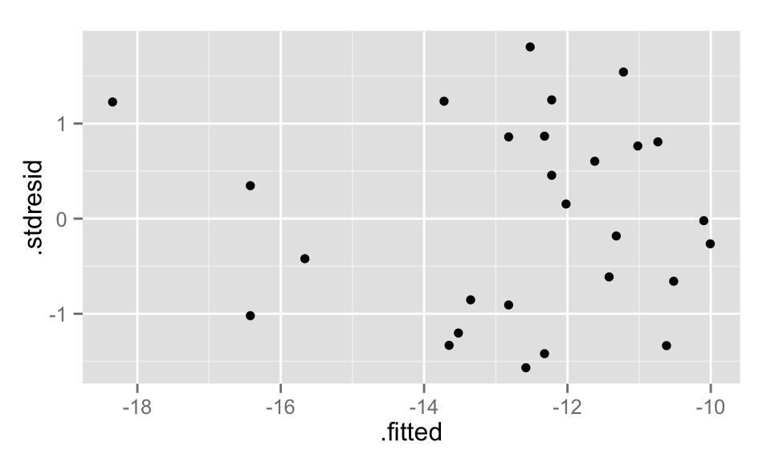

A properly specified model should be **structureless** (linearity condition) with **even spread around zero** (constant variance).

## QQ plot

Plots (standardized) **sample quantiles** on the y-axis and **theoretical quantiles** on the x-axis.

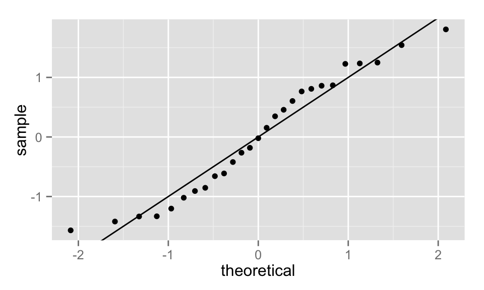

Residuals that are nearly normal will loosely follow a line, and are a good check that our normal error assumption is reasonable.

## Modeling unemployment and elections

The diagnostic plots reveal that our linear regression model is **valid**.

1. **Linearity**: OK
2. **Independent errors**: OK
3. **Normally distributed errors**: OK
4. **Errors with constant variance**: OK

And the relationship doesn't appear to be **statistically significant**.

```r
pt(t_stat, df = 27 - 2) * 2
```

```
## [1] 0.262
```

This data provides no evidence of an association between voting patterns for candidates from the president's party and the level of unemployment.

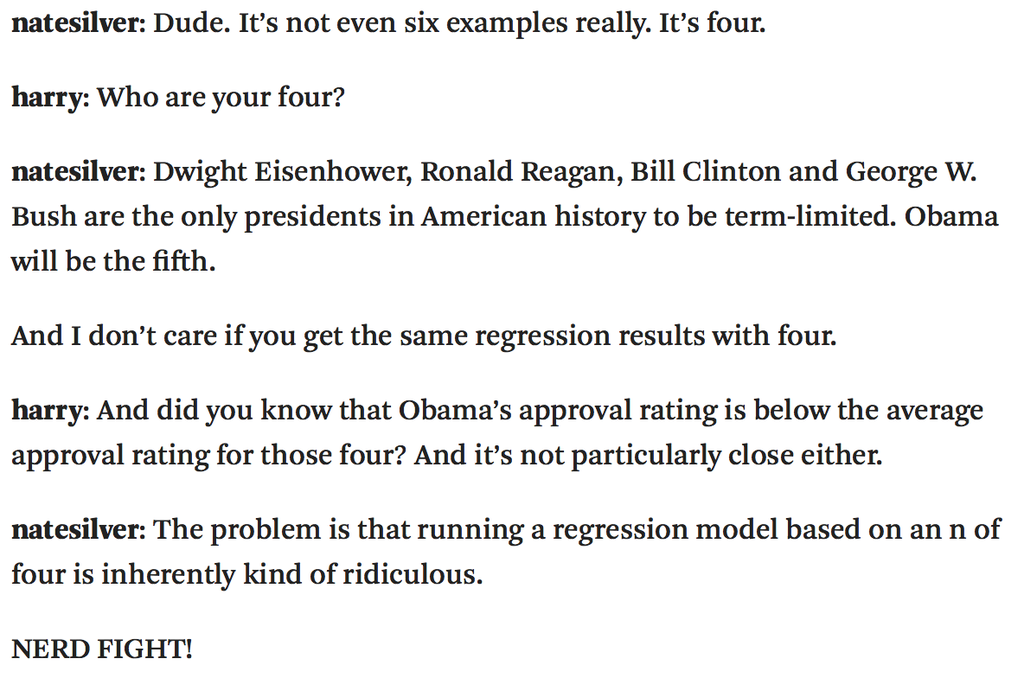